# Test Miami-Dade SIR Report

Anshul Saxena and Gabriel Odom

2020-04-06

**THIS IS A TEST OF THE REPORTING AND PUBLISHING CAPABILITIES OF THE `reticulate` PACKAGE LINKING PYTHON TO RMARKDOWN. THIS REPORT IS NOT INTENDED TO PROVIDE ANY INSIGHT INTO THE CURRENT COVID-19 PANDEMIC IN MIAMI-DADE COUNTY. INSPECT AT YOUR OWN RISK.**

## Setup

We need to load some R packages before we can perform our computing.

```r
library(reticulate)
library(tidyverse)
```

The shell script to install the packages we need is in `src/install_python_packages_20200403.sh`. This creates a conda environment called `env_sflCHIME` and activates it. At current, I have been unable to run these commands on Windows.

On Mac, I have a Conda environment created for this project. In the terminal, I type `which python` and it tells me

```bash
which python
```

```
/Users/gabrielodom/anaconda3/envs/env_sflCHIME/bin/python
```

If it says

```
/usr/bin/python
```

(or some other place), then something is wrong.

I specifically want this python environment, so I “point” `reticulate` to the particular environment that we installed with Anaconda, replete with the version of Python we selected and all associated libraries. (**NOTE**: this line must be executed before any other `reticulate` functions or Python calls, otherwise it will have no effect.)

```r
use_python(
    "/Users/gabrielodom/anaconda3/envs/env_sflCHIME/bin/python",
    required = TRUE
)
```

We also have some Python libraries to load.

```python
from functools import reduce
from typing import Tuple, Dict, Any
import pandas as pd
import streamlit as st
import numpy as np
import altair as alt
```

## Parameters

### Hospital Parameters

```python
# Regional Population
S_default = 2761581.0

# Hospital Market Share
Penn_market_share = 0.15

# Currently Hospitalised Patients (at current hospital?)
known_cases = 400.0
current_hosp = known_cases

# Currently Hospitalised Patients
known_infections = 1000.0
initial_infections = known_infections
```

### Spread and Contact Parameters

```python
# Doubling Time
doubling_time = 6.0

# Social Distancing (% reduction in social contact)
relative_contact_rate = 0.0
```

### Severity Rates

```python
# Hospitalisation (% of total infections)
hosp_rate = 0.05

# ICU (% of total infections)
icu_rate = 0.02

# Ventilated (% of total infections)
vent_rate = 0.01
```

### Severity Times

```python
# Infectious Days
recovery_days = 14.0

# Average hospital length of stay (days)
hosp_los = 7.0

# Average ICU length of stay (days)
icu_los = 9.0

# Average length of stay on a ventilator (days)
vent_los = 10.0
```

## Directly Estimated Parameters

Given the parameters above, we calculate the following disease spread parameters.

### SIR Initial Values

```python
total_infections = current_hosp / Penn_market_share / hosp_rate
print(total_infections)
```

```
## 53333.333333333336
```

```python
detection_prob = initial_infections / total_infections
print(detection_prob)
```

```
## 0.01875
```

```python
Infct = initial_infections / detection_prob
Susc, Infct, Recov = S_default - Infct, Infct, 0.0
print(Susc)
```

```
## 2708247.6666666665
```

```python
print(Infct)
# print(Recov)
# type(Recov)
```

```
## 53333.333333333336
```

```python
intrinsic_growth_rate = 2 ** (1 / doubling_time) - 1
print(intrinsic_growth_rate)
```

```
## 0.12246204830937302
```

**NOTE**: the total infections and initial infections are equal at $t = 0$.

### SIR Transition Rates

```python
# type(Recov)
# print(Recov)

gamma = 1.0 / recovery_days
# mean recovery rate, gamma, (in 1/days).
print(gamma)
```

```
## 0.07142857142857142
```

```python
beta = (intrinsic_growth_rate + gamma) / Susc * (1.0 - relative_contact_rate)
# Contact rate, beta
# {rate based on doubling time} / {initial Susc}
print(beta)
```

```
## 7.15926472029741e-08
```

```python
r_t = beta / gamma * Susc
# Current Reproduction Number
# r_t is r_0 after distancing
print(r_t)
```

```
## 2.7144686763312222
```

```python
r_naught = r_t / (1.0 - relative_contact_rate)
# Initial Reproduction Number
print(r_naught)
```

```
## 2.7144686763312222
```

```python
doubling_time_t = 1.0 / np.log2(beta * Susc - gamma + 1.0)
# Current Doubling Time
# doubling time after distancing
print(doubling_time_t)

# type(Recov)
```

```
## 5.999999999999998
```

As an aside, if I want to access any of these values in R (for instance, $R_0$), I can call them as `py$r_naught`, which yields 2.7144687.

## Model Specification

We can now specify the SIR model at outset and over time.

```python
# type(Recov)

# SIR at Outset
def sir(y, beta, gamma, N):
    S, I, R = y
    Sn = (-beta * S * I) + S
    In = (beta * S * I - gamma * I) + I
    Rn = gamma * I + R
    if Sn < 0:
        Sn = 0.0
    if In < 0:
        In = 0.0
    if Rn < 0:
        Rn = 0.0

    scale = N / (Sn + In + Rn)
    return Sn * scale, In * scale, Rn * scale
    return S, I, R

# type(Recov)

# Dynamic SIR
def sim_sir(S, I, R, beta, gamma, n_days, beta_decay = None):
    N = S + I + R
    s, i, r = [S], [I], [R]
    for day in range(n_days):
        y = S, I, R
        S, I, R = sir(y, beta, gamma, N)
        if beta_decay:
            beta = beta * (1 - beta_decay)
        s.append(S)
        i.append(I)
        r.append(R)

    s, i, r = np.array(s), np.array(i), np.array(r)
    return s, i, r

# type(Recov)

# Test Function
def test_fun(x):
  y = x + 2
  return y

# type(Recov)
```

```python
n_days = 100
beta_decay = 0.0

test_fun(3)
# type(Susc)
# type(Infct)
# type(Recov)
```

```
## 5
```

```python
y = Susc, Infct, Recov
# print(y)
# type(y)
N = Susc + Infct + Recov
print(N)
```

```
## 2761581.0
```

```python
type(N)
```

```
## <class 'float'>
```

```python
sir(y, beta, gamma, N)
```

```
## (2697906.8336139764, 59864.6425764999, 3809.5238095238096)
```

```python
s, i, r = sim_sir(
  Susc, Infct, Recov, beta, gamma, n_days, beta_decay = beta_decay
)
```

**ERROR**: `Error in py_call_impl(callable, dots$args, dots$keywords) :` `TypeError: unsupported operand type(s) for +: 'float' and 'type'`  
**SOLUTION**: I can’t have a Python object named `R`.

We now inspect the results of this model

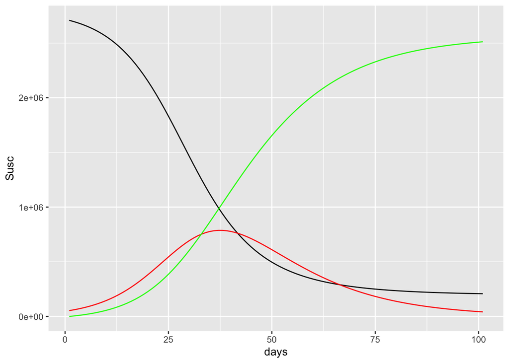

```r
res_df <- tibble(
    days  = seq_len(py$n_days + 1),
    Susc  = py$s,
    Infct = py$i,
    Recov = py$r
)

ggplot(data = res_df) +
    aes(x = days) +
    geom_line(aes(y = Susc), colour = "black") +
    geom_line(aes(y = Infct), colour = "red") +
    geom_line(aes(y = Recov), colour = "green")
```